## NYC Schools Arts Survey Data

The [2017-2018 Arts Survey Data](https://data.cityofnewyork.us/Education/2017-2018-Arts-Survey-Data/475h-cg5t) has data about arts teachers, budgets, partnerships with cultural organizations and parental involvement in NYC public schools.

In an effort to gain greater context for this data, we can examine it in conjuction with publicly available [ELA and Math state test results](https://infohub.nyced.org/reports-and-policies/citywide-information-and-data/test-results) and [demographic data](https://data.cityofnewyork.us/Education/2013-2018-Demographic-Snapshot-School/s52a-8aq6).

My goals were to understand the state of arts programs in NYC schools, what variables affect the resources of arts programs, and whether arts programs have an effect on the academic performance of students.

### Arts Education Liaison

In 2018, 1265 schools were surveyed. Schools were asked whether they have a designated arts supervisor. 5.6%, 72 schools, had no arts supervisor. My first question has to do with whether there is any relation between the presence of an arts supervisor and the demographics of the student population.

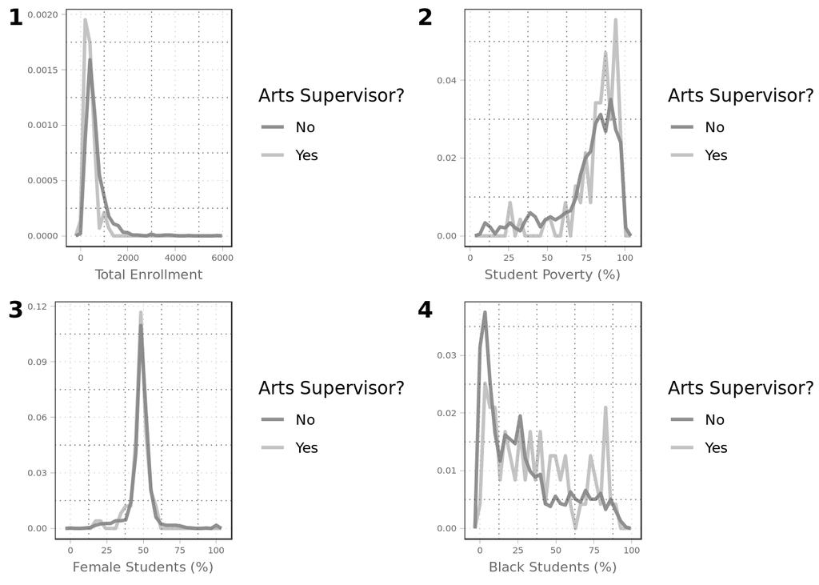

In order to assess the significance of the differences pointed we see above, we can try to fit a logistic regression to the relationship between each variable and the binary response “Does the school have an an arts supervisor?”

These regressions lend support to the differences spotted in the plots of student poverty and race, but the most statistically significant coefficient comes from total enrollment. The coefficient for total enrollment is negative with a p-value below a significance level of 0.001. Percentages of impoverished and black students have positive coefficients with p-values below a significance level of 0.01. As we had assumed from the graphs, there was no significant relation between gender and whether a school had an arts supervisor.  
In order to better interpret these results I converted the standard R logistic regression coefficients into relative risk, [as seen here](https://www.bmj.com/content/348/bmj.f7450.full?ijkey=NHT1YVsoX1RCm8r&keytype=ref).

```
## $total_enrollment_2017
## [1] 0.9975802
##
## $perc_pov_2017
## [1] 1.021338
##
## $perc_black_2017
## [1] 1.012599
```

An increase in total enrollment of one student is associated with a .25% decrease in the likelihood that a school has an arts supervisor. An increase of one percentage point in student poverty and in share of black students is associated with 2.13% and 1.26% increases, respectively, in the likelihood that a school has an arts supervisor.

Consider the possibility that there is confounding between these variables, ie. small schools tend to serve poor, mostly black student populations. To address this possibility I ran a logistic regression upon total enrollment, student poverty and share of black students. This yielded only one significant feature, total enrollment, supporting some sort of statistical interdependence between the variables.  
Let S denote school art supervisor, E enrollment, P poverty and B black students.

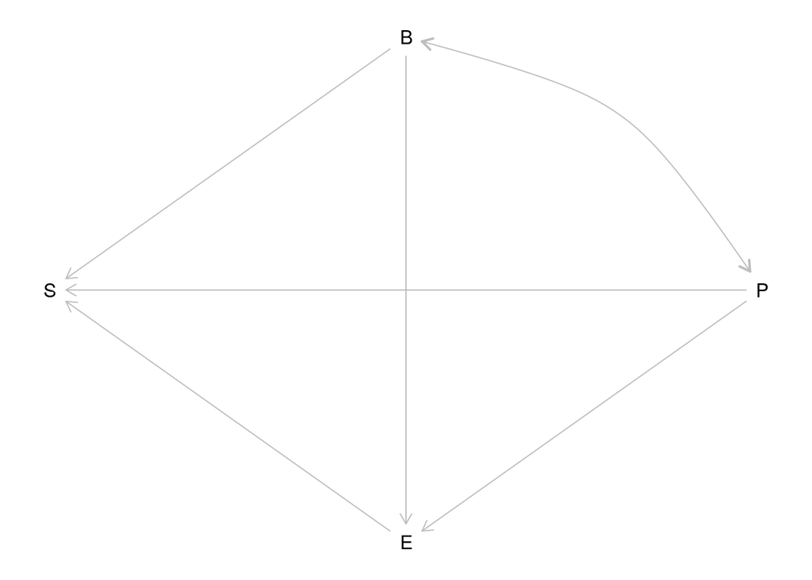

To further investigate confounding, I ran a linear model for total enrollment on percentage of impoverished and black students. As suspected, both had negative relationships with total enrollment. In particular, with a p-value less than significance level 0.001, each additional percentage point of black students was associated with a decrease of 5.22 students.

As a former NYC public school student this coincides with my experience of the school system. In my old neighborhood of Canarsie in Brooklyn was a school previously known as South Shore High School. It served thousands of poor, majority minority students. In 2010, the school was converted into the [South Shore Educational Complex](https://insideschools.org/school/18K515) and now houses five smaller high schools. A naive observer could be expected to assume that small schools have higher faculty:student ratios and more resources to expend on their students. In reality the policies of the NYC DOE have led to the exact opposite, with underperforming schools split up without necessarily being given the resources to turn around their performance.

My second question is whether there is any relation between having an arts supervisor and student academic performance.

```
##
## Call:
## lm(formula = perc_34_all_2018_ela ~ ., data = .)
##
## Residuals:
##     Min      1Q  Median      3Q     Max
## -46.914 -16.395  -3.014  15.136  62.224
##
## Coefficients:
##             Estimate Std. Error t value Pr(>|t|)
## (Intercept)  46.9138     0.6966  67.346  < 2e-16 ***
## Q2_1        -11.0378     2.9472  -3.745 0.000192 ***
## ---
## Signif. codes:  0 '***' 0.001 '**' 0.01 '*' 0.05 '.' 0.1 ' ' 1
##
## Residual standard error: 20.25 on 893 degrees of freedom
##   (370 observations deleted due to missingness)
## Multiple R-squared:  0.01546,    Adjusted R-squared:  0.01436
## F-statistic: 14.03 on 1 and 893 DF,  p-value: 0.0001918
```

```
##
## Call:
## lm(formula = perc_34_all_2018_ela ~ ., data = .)
##
## Residuals:
##     Min      1Q  Median      3Q     Max
## -33.682  -9.306  -1.539   7.298  53.259
##
## Coefficients:
##                        Estimate Std. Error t value Pr(>|t|)
## (Intercept)           94.734711   1.802482  52.558  < 2e-16 ***
## Q2_1                  -2.866684   1.844428  -1.554 0.120483
## perc_pov_2017         -0.638242   0.020032 -31.860  < 2e-16 ***
## perc_black_2017       -0.119648   0.017993  -6.650 5.12e-11 ***
## total_enrollment_2017  0.004533   0.001353   3.350 0.000843 ***
## ---
## Signif. codes:  0 '***' 0.001 '**' 0.01 '*' 0.05 '.' 0.1 ' ' 1
##
## Residual standard error: 12.49 on 890 degrees of freedom
##   (370 observations deleted due to missingness)
## Multiple R-squared:  0.6267, Adjusted R-squared:  0.625
## F-statistic: 373.5 on 4 and 890 DF,  p-value: < 2.2e-16
```

```
##
## Call:
## lm(formula = perc_34_all_2018_math ~ ., data = .)
##
## Residuals:
##     Min      1Q  Median      3Q     Max
## -43.595 -18.795  -4.495  16.955  68.652
##
## Coefficients:
##             Estimate Std. Error t value Pr(>|t|)
## (Intercept)  43.5953     0.7969  54.705  < 2e-16 ***
## Q2_1        -14.0473     3.3716  -4.166  3.4e-05 ***
## ---
## Signif. codes:  0 '***' 0.001 '**' 0.01 '*' 0.05 '.' 0.1 ' ' 1
##
## Residual standard error: 23.17 on 893 degrees of freedom
##   (370 observations deleted due to missingness)
## Multiple R-squared:  0.01907,    Adjusted R-squared:  0.01797
## F-statistic: 17.36 on 1 and 893 DF,  p-value: 3.397e-05
```

```
##
## Call:
## lm(formula = perc_34_all_2018_math ~ ., data = .)
##
## Residuals:
##     Min      1Q  Median      3Q     Max
## -40.137 -10.644  -2.267   8.213  63.174
##
## Coefficients:
##                        Estimate Std. Error t value Pr(>|t|)
## (Intercept)           92.029270   2.178865  42.237  < 2e-16 ***
## Q2_1                  -4.442436   2.229570  -1.993   0.0466 *
## perc_pov_2017         -0.629027   0.024215 -25.976  < 2e-16 ***
## perc_black_2017       -0.219982   0.021750 -10.114  < 2e-16 ***
## total_enrollment_2017  0.006570   0.001636   4.016 6.42e-05 ***
## ---
## Signif. codes:  0 '***' 0.001 '**' 0.01 '*' 0.05 '.' 0.1 ' ' 1
##
## Residual standard error: 15.1 on 890 degrees of freedom
##   (370 observations deleted due to missingness)
## Multiple R-squared:  0.5847, Adjusted R-squared:  0.5828
## F-statistic: 313.2 on 4 and 890 DF,  p-value: < 2.2e-16
```

Next time, I will continue going through the survey. The presence of an arts supervisor does not necessarily equate to a well-resourced and efficacious arts program, so I hope to find some interesting questions.